# MEDB 5501, Module 13

2024-11-12

## Topics to be covered

- What you will learn
  - The two by two crosstabulaton
  - Test of equality of two proportions
  - Sample size calculations
  - R code
  - Your homework

## Listing of titanic.yaml, 1

```
---
data_dictionary: titanic.txt

description: >
  The Titanic was a large cruise ship, the biggest of its kind in 1912. It was
  thought to be unsinkable, but when it set sail from England to America in its
  maiden voyage, it struck an iceberg and sank, killing many of the passengers
  and crew. You can get fairly good data on the characteristics of passengers
  who died and compare them to those that survived. The data indicate a strong
  effect due to age and gender, representing a philosophy of "women and children
  first" that held during the boarding of life boats.

additional_description:
  http://www.statsci.org/data/general/titanic.html
```

## Listing of titanic.yaml, 2

```
download_url:
  - http://www.statsci.org/data/general/titanic.txt

format:
  tab-delimited

varnames:
  first row of data

missing_value_code:
  NA
```

## Listing of titanic.yaml, 3

```
size:
  rows: 1313
  columns: 5

vars:
  Name:
    label: Passenger name

  PClass:
    label: Passenger class
    scale: ordinal
    values: 1st, 2nd, 3rd
```

## Listing of titanic.yaml, 4

```
  Age:
    unit: years
    scale: ratio
    range: positive real numbers
    missing: NA

  Sex:
    scale: binary
    values: female, male
```

## Listing of titanic.yaml, 5

```
  Survived:
    scale: binary
    values:
      1: yes
      0: no
---
```

## The crosstabulation of two binary variables

```
            Variable2
             0   1
Variable1 0 n00 n10
          1 n01 n11
```

## Example: Titanic data

- Crosstabulation

```
        survived
sex      yes  no
  female 308 154
  male   142 709
```

## Multiple ways to display, 1

- Crosstabulation

```
        survived
sex      yes  no
  female 308 154
  male   142 709
```

- Swap rows

```
        survived
sex      yes  no
  male   142 709
  female 308 154
```

- Swap columns

```
        survived
sex       no yes
  female 154 308
  male   709 142
```

- Swab both

```
        survived
sex       no yes
  male   709 142
  female 154 308
```

## Multiple ways to display, 2

- Transposed

```
        sex
survived female male
     yes    308  142
     no     154  709
```

- Transposed, swap rows

```
        sex
survived female male
     no     154  709
     yes    308  142
```

- Transposed, swap columns

```
        sex
survived male female
     yes  142    308
     no   709    154
```

- Transposed, swab both

```
        sex
survived male female
     no   709    154
     yes  142    308
```

## Row and column percents

- Crosstabulation with row totals

```
        survived
sex      yes  no Sum
  female 308 154 462
  male   142 709 851
```

- Row percents

```
        survived
sex            yes        no       Sum
  female 0.6666667 0.3333333 1.0000000
  male   0.1668625 0.8331375 1.0000000
```

- Cross tabulation with column totals

```
        survived
sex      yes  no
  female 308 154
  male   142 709
  Sum    450 863
```

- Column percents

```
        survived
sex            yes        no
  female 0.6844444 0.1784473
  male   0.3155556 0.8215527
  Sum    1.0000000 1.0000000
```

## Cell percents

- Cell totals

```
        survived
sex       yes   no  Sum
  female  308  154  462
  male    142  709  851
  Sum     450  863 1313
```

- Cell percents

```
        survived
sex            yes        no       Sum
  female 0.2345773 0.1172887 0.3518660
  male   0.1081493 0.5399848 0.6481340
  Sum    0.3427266 0.6572734 1.0000000
```

## My recommendation

```
        survived
sex            yes        no
  female 0.6666667 0.3333333
  male   0.1668625 0.8331375
```

## Always round, 1

```
  0.6666667
- 0.1668625
  ---------
  ?????????
```

## Always round, 1

```
  0.67
- 0.17
  ----
  ????
```

## Break #1

- What you have learned
  - The two by two crosstabulaton
- What’s coming next
  - Test of equality of two proportions

## The binomial distribution

- You have n trials of an “experiment”
- Two outcomes, “success” or “failure”
- $\pi$ is probability of success
- Each trial is independent

## Example, creating a family of three children, 1

- You have 3 trials (pregnancies)
- Two outcomes, girl (success) or boy (failure)
- $\pi$ = 0.5 is probability of success
- Each child is independent

## Example, creating a family of three children, 2

- Eight possible outcomes
  - X=0, BBB
  - X=1, BBG, BGB, GBB
  - X=2, BGG, GBG, GGB
  - X=3, GGG

## Example, creating a family of three children, 3

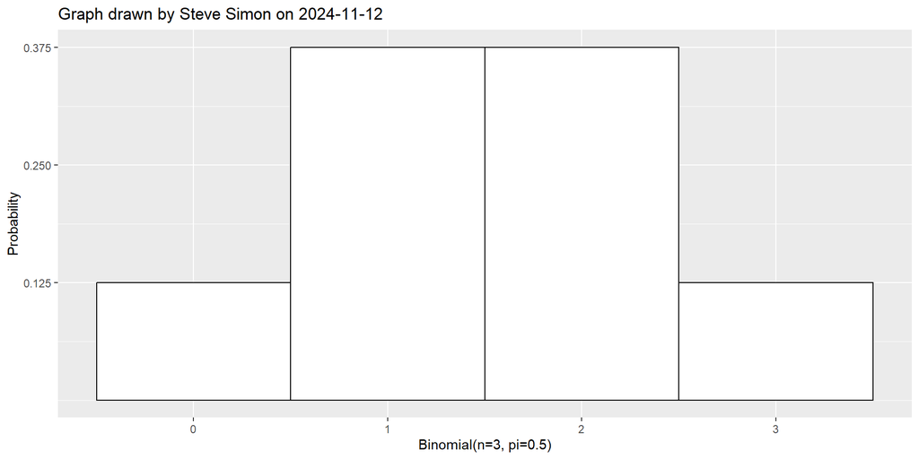

## Example, Binomial(n=10, pi=0.2)

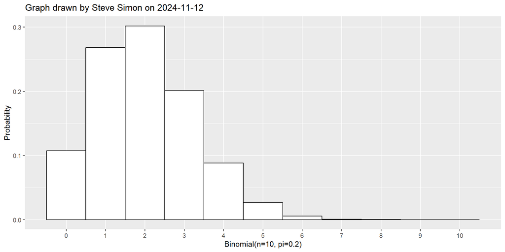

## Example, Binomial(n=20, pi=0.75)

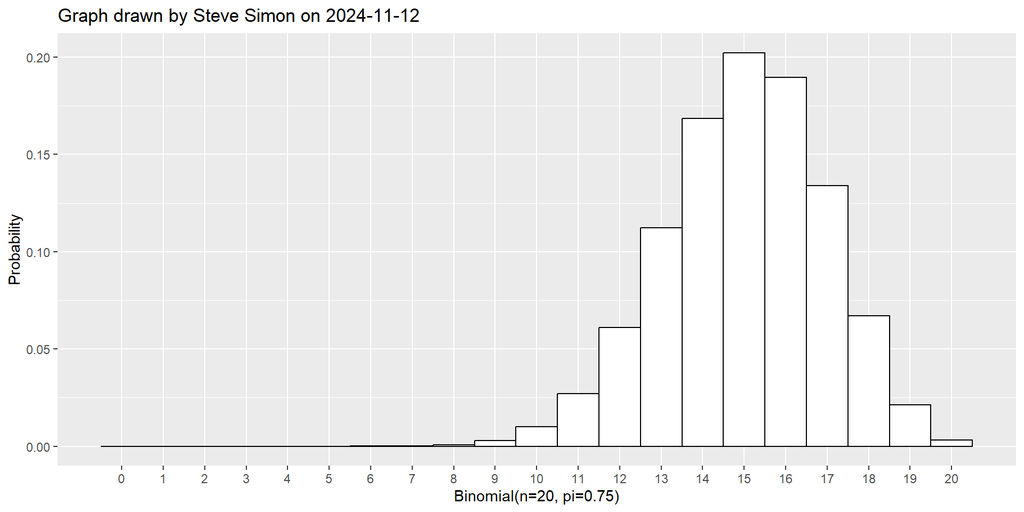

## Two proportions model, 1

- Scenario 1
  - $X_1$ is a random binomial($n_1$, $pi_1$)
  - $X_2$ is a random binomial($n_2$, $pi_2$)
  - $X_1$ and $X_2$ are independent

## Two proportions model, 2

- Scenario 2
  - Sample $X_{11}, X_{12}, ..., X_{1n_1}$
  - Sample $X_{21}, X_{22}, ..., X_{2n_2}$
  - Only possible values are 0, 1
  - $P[X_{1i}=1]=\pi_1$, $P[X_{2i}=1]=\pi_2$

## Two proportions model, 3

- $H_0:\ \pi_1 - \pi_2 = 0$
- $H_1:\ \pi_1 - \pi_2 \ne 0$

## Two proportions model, 4

- $T = \frac{p_1-p_2}{se}$
  - $se=\sqrt{\bar{p}(1-\bar{p}(\frac{1}{n_1}+\frac{1}{n_2})}$
  - $\bar{p}=\frac{n_1p_1+n_2p_2}{n_1+n_2}$
- Accept $H_0$ if T is close to zero.
  - If $Z(\alpha/2) < T < Z(1-\alpha/2)$

## Two proportions model, 5

- p-value = $2P[Z >|T|]$
- Accept $H_0$ if p-value > $\alpha$

## Some variations of the test statistic, 1

- Yates continuity correction
  - $T = \frac{p_1-p_2 + c}{se}$
  - Formula for c is messy
  - Net effect is to pull T closer to zero
  - Better to meet the normal approximation

## Some variations of the test statistic, 2

- Chi-squared test
  - $T = \Big(\frac{p_1-p_2}{se}\Big)^2$
  - Accept $H_0$ if T < $\chi^2(1-\alpha, df=1)$
  - p-value = $P[\chi^2(df=1) > T]$
  - Does not allow for easy test of one-sided hypothesis
- Chi-squared test with Yates continuity correction
  - $T = \Big(\frac{p_1-p_2 + c}{se}\Big)^2$

## One-sided test, 1

- $H_0:\ \pi_1 - \pi_2 = 0$
- $H_1:\ \pi_1 - \pi_2 > 0$
  - Accept $H_0$ if T < $z(1-\alpha)$
  - p-value = $P[Z > T]$
  - Accept $H_0$ if p-value > $\alpha$

## One-sided test, 2

- $H_0:\ \pi_1 - \pi_2 = 0$
- $H_1:\ \pi_1 - \pi_2 < 0$
  - Accept $H_0$ if T > $z(\alpha)$
  - p-value = $P[Z < T]$
  - Accept $H_0$ if p-value > $\alpha$

## Two sample test of proportions with Titanic data, 1

```
        survived
sex      yes  no
  female 308 154
  male   142 709
```

## Two sample test of proportions with Titanic data, 2

```
        survived
sex            yes        no
  female 0.6666667 0.3333333
  male   0.1668625 0.8331375
```

## Two sample test of proportions with Titanic data, 3

```
    2-sample test for equality of proportions without continuity correction

data:  table1
X-squared = 332.06, df = 1, p-value < 2.2e-16
alternative hypothesis: two.sided
95 percent confidence interval:
 0.4500519 0.5495564
sample estimates:
   prop 1    prop 2
0.6666667 0.1668625
```

## Break #2

- What you have learned
  - Test of equality of two proportions
- What’s coming next
  - Sample size calculations

## What you need for a continuous outcome

- Research hypothesis
- Standard deviation of your outcome measure
- Minimum clinically important difference
- Other details
  - Type I error rate (usually 0.05)
  - Power (usually 0.90)

## What you need for a categorical outcome

- Research hypothesis
- Expected proportion in the control group
- Minimum clinically important difference

## Hypothetical scenario, 1

- Weight loss study
  - Control is recommended diet and exercise routine
  - Treatment adds experimental weight loss drug
  - Binary event, losing at least 5 pounds after 6 months
- Hypothesis proportion is higher in treatment group than control
- Proportion in control group is 10%
- Need to see at least 5% more events in treatment group

## Hypothetical scenario, 2

- Set power to 90%
- Set Type I error rate (alpha) to 5%

```r
power.prop.test(
    p1=0.10,
    p2=0.15,
    power=0.9,
    sig.level=0.05)
```

```
     Two-sample comparison of proportions power calculation

              n = 917.3206
             p1 = 0.1
             p2 = 0.15
      sig.level = 0.05
          power = 0.9
    alternative = two.sided

NOTE: n is number in *each* group
```

## Rule of 50

- Want to detect a doubling or halving
- Need 25 to 50 events in each group
- Example
  - Control probability is 0.1
  - Want to see 20% in treatment group
  - 25/0.1 = 250; 50/0.1 = 500

## Break #3

- What you have learned
  - Sample size calculations
- What’s coming next
  - R code

## Listing of simon-5501-13-titanic.qmd, 1

```
---
title: "Analysis of Titanic dataset"
format:
  html:
    embed-resources: true
---

This program reads data on survival of passengers on the Titanic. Find more
information in the [data dictionary][dd].

[dd]: https://github.com/pmean/data/blob/main/files/titanic.yaml

This code was written by Steve Simon on 2024-11-09 and is placed in the public
domain.
```

## Listing of simon-5501-13-titanic.qmd, 2

````
## Load the tidyverse library

```{r}
#| label: setup
#| message: false
#| warning: false
library(broom)
library(epitools)
library(tidyverse)
```
````

## Listing of simon-5501-13-titanic.qmd, 3

```
#### Comments on the code

For most of your programs, you should load the [tidyverse library][tid1]. The messages and warnings are suppressed.

[tid1]: https://www.tidyverse.org/

In previous programs, I put a label for each chunk inside the curly braces ({}).
It is recommended instead to put the label on a separate line inside the program
chunk. It is a bit more work to provide a unique label for each chunk, but it
helps quite a bit to isolate where to look when your code produces an error.
```

## Listing of simon-5501-13-titanic.qmd, 4

````
## Read the data and view a brief summary

```{r}
#| label: read
ti <- read_tsv(
  file="../data/titanic.txt",
  col_names=TRUE,
  col_types="ccncn",
  na="NA")
names(ti) <- tolower(names(ti))
glimpse(ti)
```
````

## Listing of simon-5501-13-titanic.qmd, 5

```
#### Comments on the code

Use read_tsv from the [readr package][rea1] to  read this file. Use
col_names=TRUE because the column names are included as the first row of the
file. The col_types="ccncn" specifies the first second and fourth columns as
strings and the third and fifth as numeric. There are missing values in this
dataset, designated by the letters "NA".

[rea1]: https://readr.tidyverse.org/
```

## Listing of simon-5501-13-titanic.qmd, 6

````
## Replace numeric codes for survived

```{r}
#| label: replace-numbers
ti$survived <-
    factor(
        ti$survived,
        level=1:0,
        labels=c("yes", "no"))
```
````

## Listing of simon-5501-13-titanic.qmd, 7

````
## Get counts of sex by survival

```{r}
#| label: counts
table1 <-xtabs(~sex+survived, data=ti)
table1
```
````

## Listing of simon-5501-13-titanic.qmd, 8

```
#### Comments on the code

The [table function][tab1] or the [xtabs function][xta1] creates a matrix with the number of observations in each combination of sex and survived. These values are placed in a single column. The [xtabs function][xta1] or the [count function][cou1] provide slightly different approaches.

[cou1]: https://dplyr.tidyverse.org/reference/count.html
[tab1]: https://stat.ethz.ch/R-manual/R-devel/library/base/html/table.html
[xta1]: https://stat.ethz.ch/R-manual/R-devel/library/stats/html/xtabs.html

#### Interpretation of the output

There are 154 female passengers who died and 308 who survived. There are 709 male passengers who died and 142 who survived.
```

## Listing of simon-5501-13-titanic.qmd, 9

````
## Get proportions for died/survived by sex

```{r}
#| label: proportions
table1 |>
  proportions("sex")
```

#### Comments on the code

The [proportions function][pro1] calculate proportions for a matrix, either by row (margin=1), by column (margin=2) or across all cells (margin=NULL).

[pro1]: https://stat.ethz.ch/R-manual/R-devel/library/base/html/proportions.html
````

## Listing of simon-5501-13-titanic.qmd, 10

```
#### Interpretation of the output

The proportion of women who died is 33%. The proportion of men who died is much higher at 83%.
```

## Listing of simon-5501-13-titanic.qmd, 11

````
## Bar chart

```{r}
#| label: bar
ti |>
  ggplot() +
    aes(x = sex, fill = survived) +
    geom_bar(position = "fill") +
      xlab("Sex") +
      ylab("Proportion") +
      ggtitle("Graph drawn by Steve Simon on 2024-11-11")
```
````

## Listing of simon-5501-13-titanic.qmd, 12

````
## Hypothesis test for two proportions

```{r}
#| label: equality-of-proportions
prop.test(table1, correct=FALSE)
```

#### Comments on the code

The [prop.test function][pro2] does not work on raw data. You need to get summary counts, either from the table function or the xtabs function. The option correct=FALSE informs R to not use the [Yates continuity correction][yat1].

[pro2]: https://search.r-project.org/R/refmans/stats/html/prop.test.html
[yat1]: https://www.statskingdom.com/121proportion_normal2.html
````

## Listing of simon-5501-13-titanic.qmd, 13

[output not shown]

## Listing of simon-5501-13-titanic.qmd, 14

````
## Power calculation

```{r}
#| label: power
power.prop.test(p1=0.17, p2=0.67, power=0.9)
```
````

## Listing of simon-5501-13-titanic.qmd, 15

```
#### Comments on the code

The [power.prop.test][pow1] function will compute a sample size if you specify
the two group probabilities, the significance level, and the power. It will also
do other calculations, such as the minimum difference in probabilities that you
could detect for a specific sample size and a specific power.

[pow1]: https://stat.ethz.ch/R-manual/R-devel/library/stats/html/power.prop.test.html
```

## Listing of simon-5501-13-titanic.qmd, 16

```
#### Interpretation of the output

Clearly, a sample size of 1,313 passengers provided more than enough power and
precision, especially considering that the difference in survival rates was so
large. Out of curiosity, what sample size would still be adequate for testing a
shift of 50% from a survival rate of 17% to a survival rate of 67%? If you
wanted power to be at least 90%, then a sample size of only 19 passengers of
each sex would be needed.
```

## Listing of simon-5501-13-titanic.qmd, 17

````
## Chi-squared test

```{r}
#| label: chi-square-test
chisq.test(table1, correct=FALSE)
```
````

## Listing of simon-5501-13-titanic.qmd, 18

```
#### Comments on the code

The [chisq.test function][chi1] calculates a chi-square test of independence. It
takes input in a variety of forms. In this example, it uses a crosstabulation
computed by the xtabs command as input.

This function also will run a goodness-of-fit test, which is not discussed in
this lecture.

[chi1]: https://stat.ethz.ch/R-manual/R-devel/library/stats/html/chisq.test.html
```

## Listing of simon-5501-13-titanic.qmd, 19

````
#### Interpretation of the output

The chi-squared statistic is much larger than the degrees of freedom and the
p-value is small. You should reject the null hypothesis and conclude that sex
and survival are related (not independent)

## Fisher's Exact test

```{r}
#| label: fishers-exact
fisher.test(table1)
```
````

## Listing of simon-5501-13-titanic.qmd, 20

```
#### Comments on the code

The [fisher.test function][fis1] calculates the Fisher's exact test, which is
helpful for small sample sizes. The 1,313 passengers on the Titanic do not
constitute a small sample size by any means. This test is just shown as an
example of how to calculate this test.

[fis1]: https://stat.ethz.ch/R-manual/R-devel/library/stats/html/fisher.test.html
```

## Listing of simon-5501-13-titanic.qmd, 21

````
#### Interpretation of the output

The p-value is small. You should reject the null hypothesis and conclude that
sex and survival are related (not independent). The estimated odds ratio is
9.97. The confidence interval for the odds ratio excludes the value of 1
leading to the same conclusion. In fact, even after allowing for sampling error
that odds of survival are at least 7.6 times greater for women than for me.

## Odds ratio calculation

```{r}
#| label: odds-ratio
oddsratio(table1)
```
````

## Listing of simon-5501-13-titanic.qmd, 22

```
#### Comments on the code

The oddsratio function and riskratio function (see below) are part of the
[epitools library][epi1]. It produces an odds ratio and confidence interval
and p-values associated with the Fisher's Exact test and the Chi-squared test of
independence.

[epi1]: https://cran.r-project.org/web/packages/epitools/epitools.pdf
```

## Listing of simon-5501-13-titanic.qmd, 23

```
#### Interpretation of the output

We are 95% confident that the odds ratio of survival for women versus men is at
least 7.7 and possibly as large as 13, after accounting for sampling error.
This interval excludes the value of 1, so you can conclude that the risk of
death is much higher for men than for women. Equivalently you could conclude
that the odds of survival are much higher for women than for men.
```

## Listing of simon-5501-13-titanic.qmd, 24

[output not shown]

## Listing of simon-5501-13-titanic.qmd, 25

````
## Risk ratio calculation, 2

```{r}
#| label: risk-ratio-2
riskratio(table1)
```

#### Interpretation of the output

The risk ratio is comparing the probability of death between men and women. Men have 2.5 times higher probability of death compared to women. The confidence interval excludes the value of 1, indicating a statistically significant increase.
````

## Listing of simon-5501-13-titanic.qmd, 26

````
## Risk ratio calculation, 3

```{r}
#| label: risk-ratio-3
riskratio(table1, rev="columns")
```

#### Interpretation of the output

The risk ratio is comparing the probability of survival between men and women. Men has one-fourth the probability of survival compared to women. The confidence interval excludes the value of 1, indicating that men have a statistically significantly lower probability of survival compared to women.
````

## Listing of simon-5501-13-titanic.qmd, 27

````
## Save data for later use

```{r save}
save(ti, file="../data/titanic.RData")
```

#### Comments on the code

It is usually a good idea to [save][sav1] your data in an RData file to make it
easier to retrieve this data later (with the [load function][loa1]).

[sav1]: https://stat.ethz.ch/R-manual/R-devel/library/base/html/save.html
[loa1]: https://stat.ethz.ch/R-manual/R-devel/library/base/html/save.html
````

## Ch-squared

## Summary

- What you have learned
  - The two by two crosstabulaton
  - Test of equality of two proportions
  - Sample size calculations
  - R code
  - Your homework